# Circulating GLUL, ALDH2, ECHS1 and SCP2 in IPMN — discovery-locked cut-offs and external validation

This notebook reproduces the plasma-protein analyses of the manuscript (main Figure 5, Supplementary Figure 5, Supplementary Table 6).

**Design.** GLUL, ALDH2, ECHS1 and SCP2 were pre-specified upstream of this analysis (differential abundance, spatial transcriptomics and tissue validation; see manuscript). Because that selection used the discovery cohort, the discovery cohort is used here **only** to derive one classification cut-off per protein (Youden’s index), which is then locked. **All performance estimates are computed in the independent validation cohort.** No multivariable model is fitted.

**Contrasts.**

- Primary: HG-IPMN + PDAC vs LG-IPMN (`malignant_PDAC`)
- Secondary (exploratory, 9 events in validation): HG-IPMN vs LG-IPMN, PDAC excluded (`malignant_IPMN`)

Run from the repository root (knitting this file does that automatically). All outputs are written to `output/`.

```r
library(readxl)
library(dplyr)
library(ggplot2)
library(patchwork)
library(pROC)
library(cutpointr)
library(cvms)
library(writexl)

PATH    <- "Data/Cohorts.xlsx"
MARKERS <- c("GLUL", "ALDH2", "ECHS1", "SCP2")
BOOT_N  <- 2000
SEED    <- 42

dir.create("output", showWarnings = FALSE)
```

# Data

```r
load_cohort <- function(path, cohort) {
  as.data.frame(read_xlsx(path, sheet = cohort)) %>%
    mutate(
      # Primary contrast: HG-IPMN or PDAC = 1, LG-IPMN = 0
      malignant_PDAC = as.integer(Type %in% c("High-Grade IPMN", "PDAC")),
      # Secondary contrast: HG-IPMN = 1, LG-IPMN = 0, PDAC excluded (NA)
      malignant_IPMN = case_when(
        Type == "High-Grade IPMN" ~ 1L,
        Type == "Low-Grade IPMN"  ~ 0L,
        TRUE                      ~ NA_integer_
      ),
      # CA19-9 binary call; "miss" = not recorded (NA, never treated as negative)
      ca19_pos = case_when(
        trimws(Ca19) == "pos" ~ 1L,
        trimws(Ca19) == "neg" ~ 0L,
        TRUE                  ~ NA_integer_
      )
    )
}

df_disc <- load_cohort(PATH, "Discovery")
df_val  <- load_cohort(PATH, "Validation")

table(Discovery  = df_disc$Type)
```

```
## Discovery
## High-Grade IPMN  Low-Grade IPMN            PDAC
##              14              24              18
```

```r
table(Validation = df_val$Type)
```

```
## Validation
## High-Grade IPMN  Low-Grade IPMN            PDAC
##               9              46              12
```

# 1. Discrimination in the validation cohort (AUROC)

AUROC with 95% CI from 2,000 stratified bootstrap replicates.

```r
roc_ci_plot <- function(data, marker, outcome,
                        fill = "cadetblue", boot_n = BOOT_N, seed = SEED) {
  set.seed(seed)
  r <- pROC::roc(data[[outcome]], data[[marker]], percent = TRUE, quiet = TRUE,
           direction = "<", levels = c(0, 1))
  ci_se <- pROC::ci.se(r, specificities = seq(0, 100, 1), boot.n = boot_n,
                 method = "bootstrap", progress = "none")
  band  <- data.frame(specificity = seq(0, 100, 1), lo = ci_se[, 1], hi = ci_se[, 3])

  curve <- data.frame(specificity = r$specificities, sensitivity = r$sensitivities)
  curve <- curve[order(curve$specificity, curve$sensitivity), ]

  set.seed(seed)
  auc_ci  <- pROC::ci.auc(r, method = "bootstrap", boot.n = boot_n, stratified = TRUE,
                    progress = "none")
  auc_lab <- sprintf("AUC = %.1f%% (%.1f-%.1f)", as.numeric(pROC::auc(r)), auc_ci[1], auc_ci[3])

  ggplot() +
    geom_ribbon(data = band, aes(specificity, ymin = lo, ymax = hi),
                fill = fill, color = "black", alpha = 0.8) +
    geom_step(data = curve, aes(specificity, sensitivity), direction = "vh", linewidth = 0.9) +
    geom_segment(aes(x = 100, y = 0, xend = 0, yend = 100), linetype = "dashed", colour = "grey60") +
    annotate("text", x = 50, y = 5, label = auc_lab, hjust = 0.5) +
    scale_x_reverse(limits = c(100, 0), expand = c(0, 0)) +
    scale_y_continuous(limits = c(0, 100), expand = c(0, 0)) +
    coord_equal() +
    labs(title = marker, x = "Specificity (%)", y = "Sensitivity (%)") +
    theme_classic(base_size = 10) +
    theme(plot.title = element_text(face = "bold", hjust = 0.5))
}

auroc_table <- function(data, outcome, boot_n = BOOT_N, seed = SEED) {
  do.call(rbind, lapply(MARKERS, function(m) {
    r <- pROC::roc(data[[outcome]], data[[m]], quiet = TRUE, direction = "<", levels = c(0, 1))
    set.seed(seed)
    cb <- as.numeric(pROC::ci.auc(r, method = "bootstrap", boot.n = boot_n, stratified = TRUE,
                            progress = "none"))
    data.frame(marker = m,
               AUC = round(as.numeric(pROC::auc(r)), 3),
               lo  = round(cb[1], 3),
               hi  = round(cb[3], 3))
  }))
}
```

## Primary contrast — Figure 5A

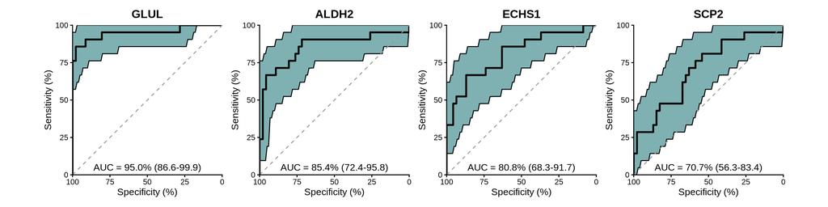

```r
plots_PDAC <- lapply(MARKERS, function(m) roc_ci_plot(df_val, m, outcome = "malignant_PDAC"))
wrap_plots(plots_PDAC, ncol = 4)
```

```r
svg("output/validation_Malignant_PDAC.svg", width = 12, height = 3)
print(wrap_plots(plots_PDAC, ncol = 4))
invisible(dev.off())

auc_df_PDAC <- auroc_table(df_val, "malignant_PDAC")
auc_df_PDAC
```

```
##   marker   AUC    lo    hi
## 1   GLUL 0.950 0.866 0.999
## 2  ALDH2 0.854 0.724 0.958
## 3  ECHS1 0.808 0.683 0.917
## 4   SCP2 0.707 0.563 0.834
```

```r
write_xlsx(auc_df_PDAC, "output/AUC_PDAC.xlsx")
```

## Secondary contrast — Supplementary Figure 5A

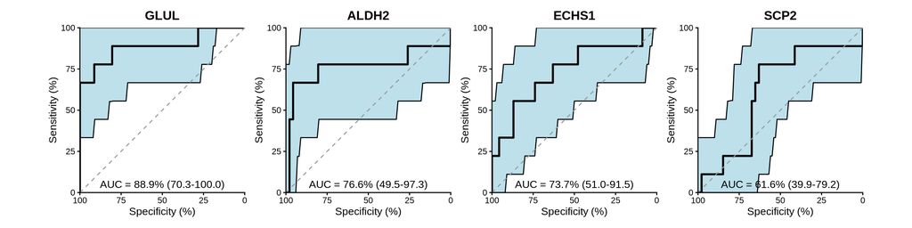

```r
plots_IPMN <- lapply(MARKERS, function(m)
  roc_ci_plot(df_val, m, outcome = "malignant_IPMN", fill = "lightblue"))
wrap_plots(plots_IPMN, ncol = 4)
```

```r
svg("output/validation_Malignant_IPMN.svg", width = 12, height = 3)
print(wrap_plots(plots_IPMN, ncol = 4))
invisible(dev.off())

auc_df_IPMN <- auroc_table(df_val, "malignant_IPMN")
auc_df_IPMN
```

```
##   marker   AUC    lo    hi
## 1   GLUL 0.889 0.703 1.000
## 2  ALDH2 0.766 0.495 0.973
## 3  ECHS1 0.737 0.510 0.915
## 4   SCP2 0.616 0.399 0.792
```

```r
write_xlsx(auc_df_IPMN, "output/AUC_IPMN.xlsx")
```

# 2. Discovery-derived cut-offs — Supplementary Table 6

One cut-off per protein and contrast, maximising Youden’s index in the discovery cohort (rule: marker >= cut-off -> positive). Where a protein separates the discovery classes completely (GLUL), every value inside the gap maximises Youden’s index; the midpoint of the gap is used.

```r
find_cutoffs <- function(data, marker, outcome) {
  x <- data[[marker]]; y <- data[[outcome]]
  keep <- !is.na(x) & !is.na(y)
  x <- x[keep]; y <- y[keep]

  cp_y <- cutpointr(x = x, class = y,
                    method = maximize_metric, metric = youden,
                    direction = ">=", pos_class = 1, neg_class = 0,
                    na.rm = TRUE, silent = TRUE)

  complete_sep <- isTRUE(cp_y$acc == 1)
  cutoff <- if (complete_sep) {
    # midpoint between the highest negative and the lowest positive value
    (max(x[y == 0]) + min(x[y == 1])) / 2
  } else {
    cp_y$optimal_cutpoint
  }

  data.frame(marker      = marker,
             youden_cut  = cutoff,
             youden_sens = round(cp_y$sensitivity, 3),
             youden_spec = round(cp_y$specificity, 3),
             complete_separation = complete_sep)
}

cutoffs_PDAC <- do.call(rbind, lapply(MARKERS, find_cutoffs, data = df_disc, outcome = "malignant_PDAC"))
cutoffs_IPMN <- do.call(rbind, lapply(MARKERS, find_cutoffs, data = df_disc, outcome = "malignant_IPMN"))
cutoffs_PDAC
```

```
##              marker youden_cut youden_sens youden_spec complete_separation
## sensitivity    GLUL    5510.45       1.000       1.000                TRUE
## sensitivity1  ALDH2    2278.70       0.969       1.000               FALSE
## sensitivity2  ECHS1   12523.40       0.812       1.000               FALSE
## sensitivity3   SCP2   19611.60       0.844       0.917               FALSE
```

```r
cutoffs_IPMN
```

```
##              marker youden_cut youden_sens youden_spec complete_separation
## sensitivity    GLUL    5510.45       1.000       1.000                TRUE
## sensitivity1  ALDH2    2278.70       0.929       1.000               FALSE
## sensitivity2  ECHS1    7983.40       0.786       0.958               FALSE
## sensitivity3   SCP2   10886.90       1.000       0.750               FALSE
```

```r
write_xlsx(cutoffs_PDAC, "output/cutoffs_PDAC.xlsx")
write_xlsx(cutoffs_IPMN, "output/cutoffs_IPMN.xlsx")
```

# 3. Locked cut-offs applied to the validation cohort

Sensitivity, specificity, PPV, NPV and accuracy with exact (Clopper–Pearson) 95% CIs; balanced accuracy with a 2,000-replicate bootstrap CI.

```r
ci_binom <- function(x, n) {
  b <- binom.test(x, n)
  c(est = x / n, lo = b$conf.int[1], hi = b$conf.int[2])
}

bal_acc <- function(truth, pred) {
  mean(c(sum(pred == 1 & truth == 1) / sum(truth == 1),
         sum(pred == 0 & truth == 0) / sum(truth == 0)))
}

# Full metric set for one binary prediction against the truth
metrics_from_pred <- function(truth, pred, label, boot_n = BOOT_N, seed = SEED) {
  tp <- sum(pred == 1 & truth == 1); fn <- sum(pred == 0 & truth == 1)
  tn <- sum(pred == 0 & truth == 0); fp <- sum(pred == 1 & truth == 0)
  n  <- tp + fn + tn + fp

  set.seed(seed)
  bs <- replicate(boot_n, { i <- sample(n, replace = TRUE); bal_acc(truth[i], pred[i]) })
  ba <- c(est = bal_acc(truth, pred),
          lo  = unname(quantile(bs, 0.025, na.rm = TRUE)),
          hi  = unname(quantile(bs, 0.975, na.rm = TRUE)))

  m <- rbind(Accuracy    = ci_binom(tp + tn, n),
             Sensitivity = ci_binom(tp, tp + fn),
             Specificity = ci_binom(tn, tn + fp),
             PPV         = ci_binom(tp, tp + fp),
             NPV         = ci_binom(tn, tn + fn),
             `Balanced accuracy` = ba)
  data.frame(predictor = label, metric = rownames(m), m,
             TP = tp, FN = fn, TN = tn, FP = fp, row.names = NULL)
}

marker_metrics <- function(marker, data, cutoffs, outcome) {
  cut  <- cutoffs$youden_cut[cutoffs$marker == marker]
  data <- data[!is.na(data[[outcome]]), ]          # secondary contrast: drops PDAC
  metrics_from_pred(data[[outcome]], as.integer(data[[marker]] >= cut), marker)
}

METRIC_ORDER <- c("Sensitivity", "Specificity", "PPV", "NPV", "Accuracy", "Balanced accuracy")

plot_metrics <- function(df, fill) {
  df$metric    <- factor(df$metric, levels = rev(METRIC_ORDER))
  df$predictor <- factor(df$predictor, levels = unique(df$predictor))
  ggplot(df, aes(est, metric)) +
    geom_pointrange(aes(xmin = lo, xmax = hi), shape = 21, fill = fill,
                    color = "black", linewidth = 0.7) +
    geom_text(aes(label = sprintf("%.2f (%.2f-%.2f)", est, lo, hi)), vjust = -0.8, size = 2.6) +
    coord_cartesian(clip = "off") +
    scale_x_continuous(limits = c(0, 1.25), breaks = seq(0, 1, 0.25), labels = scales::percent) +
    facet_wrap(~ predictor, ncol = 4) +
    labs(x = "Estimate (95% CI)", y = NULL) +
    theme_classic(base_size = 11) +
    theme(strip.background = element_blank(), strip.text = element_text(face = "bold"),
          axis.line.x = element_blank(), axis.line.y = element_blank(),
          axis.ticks.y = element_blank())
}

plot_cm <- function(truth, pred, lab, fill, ylab) {
  t <- factor(truth, levels = c(0, 1), labels = lab)   # fixed levels keep a 2x2
  p <- factor(pred,  levels = c(0, 1), labels = lab)   # even if one class is never predicted
  plot_confusion_matrix(confusion_matrix(targets = t, predictions = p),
                        add_normalized = TRUE,
                        add_col_percentages = FALSE, add_row_percentages = FALSE,
                        tile_border_color = "black", add_arrows = FALSE,
                        add_zero_shading = FALSE,
                        palette = list(low = "#EAEAEA", high = fill)) +
    labs(x = "Actual", y = ylab)
}

plot_cm_marker <- function(marker, cutoffs, data, outcome, lab, fill) {
  cut  <- cutoffs$youden_cut[cutoffs$marker == marker]
  data <- data[!is.na(data[[outcome]]), ]
  plot_cm(data[[outcome]], as.integer(data[[marker]] >= cut), lab, fill,
          paste0(marker, " - Cut-off"))
}
```

## Primary contrast — Figure 5B–C

```r
LAB_PDAC <- c("LG-IPMN", "HG-IPMN/PDAC")

met_PDAC <- do.call(rbind, lapply(MARKERS, marker_metrics, data = df_val,
                                  cutoffs = cutoffs_PDAC, outcome = "malignant_PDAC"))
met_PDAC
```

```
##    predictor            metric       est        lo        hi TP FN TN FP
## 1       GLUL          Accuracy 0.9402985 0.8541368 0.9834956 18  3 45  1
## 2       GLUL       Sensitivity 0.8571429 0.6365760 0.9695110 18  3 45  1
## 3       GLUL       Specificity 0.9782609 0.8847282 0.9994498 18  3 45  1
## 4       GLUL               PPV 0.9473684 0.7397193 0.9986684 18  3 45  1
## 5       GLUL               NPV 0.9375000 0.8280401 0.9869208 18  3 45  1
## 6       GLUL Balanced accuracy 0.9177019 0.8309006 0.9900000 18  3 45  1
## 7      ALDH2          Accuracy 0.8358209 0.7251992 0.9150875 14  7 42  4
## 8      ALDH2       Sensitivity 0.6666667 0.4303245 0.8541231 14  7 42  4
## 9      ALDH2       Specificity 0.9130435 0.7920827 0.9757969 14  7 42  4
## 10     ALDH2               PPV 0.7777778 0.5236272 0.9359080 14  7 42  4
## 11     ALDH2               NPV 0.8571429 0.7275785 0.9405785 14  7 42  4
## 12     ALDH2 Balanced accuracy 0.7898551 0.6824276 0.8949065 14  7 42  4
## 13     ECHS1          Accuracy 0.7910448 0.6743367 0.8807882 10 11 43  3
## 14     ECHS1       Sensitivity 0.4761905 0.2571306 0.7021932 10 11 43  3
## 15     ECHS1       Specificity 0.9347826 0.8210356 0.9863432 10 11 43  3
## 16     ECHS1               PPV 0.7692308 0.4618685 0.9496189 10 11 43  3
## 17     ECHS1               NPV 0.7962963 0.6646951 0.8936807 10 11 43  3
## 18     ECHS1 Balanced accuracy 0.7054865 0.5953528 0.8187018 10 11 43  3
## 19      SCP2          Accuracy 0.6417910 0.5153035 0.7553051 12  9 31 15
## 20      SCP2       Sensitivity 0.5714286 0.3402063 0.7818031 12  9 31 15
## 21      SCP2       Specificity 0.6739130 0.5198280 0.8046746 12  9 31 15
## 22      SCP2               PPV 0.4444444 0.2547988 0.6467358 12  9 31 15
## 23      SCP2               NPV 0.7750000 0.6154883 0.8916034 12  9 31 15
## 24      SCP2 Balanced accuracy 0.6226708 0.5012881 0.7465615 12  9 31 15
```

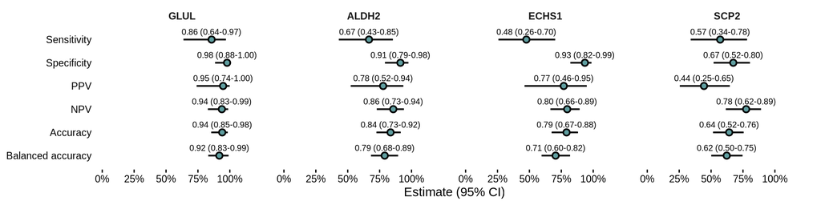

```r
write_xlsx(met_PDAC, "output/metrics_PDAC.xlsx")

p <- plot_metrics(met_PDAC, "cadetblue"); p
```

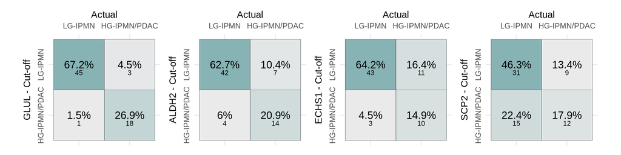

```r
svg("output/metrics_PDAC.svg", width = 7.5, height = 2.5); print(p); invisible(dev.off())

cm_plots <- lapply(MARKERS, plot_cm_marker, cutoffs = cutoffs_PDAC, data = df_val,
                   outcome = "malignant_PDAC", lab = LAB_PDAC, fill = "cadetblue")
png("output/cm_Malignant_PDAC.png", width = 10, height = 2.5, res = 300, units = "in")
print(wrap_plots(cm_plots, ncol = 4)); invisible(dev.off())
png("output/cm_Malignant_PDACv.png", width = 5, height = 5, res = 300, units = "in")
print(wrap_plots(cm_plots, ncol = 2)); invisible(dev.off())
wrap_plots(cm_plots, ncol = 4)
```

Sensitivity of GLUL within the malignant class, by histology (shows how much of the primary endpoint is carried by PDAC):

```r
glul_cut_PDAC <- cutoffs_PDAC$youden_cut[cutoffs_PDAC$marker == "GLUL"]
df_val %>%
  filter(malignant_PDAC == 1) %>%
  group_by(Type) %>%
  summarise(n = n(), detected = sum(GLUL >= glul_cut_PDAC),
            sensitivity = detected / n,
            lo = binom.test(detected, n)$conf.int[1],
            hi = binom.test(detected, n)$conf.int[2])
```

```
## # A tibble: 2 × 6
##   Type                n detected sensitivity    lo    hi
##   <chr>           <int>    <int>       <dbl> <dbl> <dbl>
## 1 High-Grade IPMN     9        6       0.667 0.299 0.925
## 2 PDAC               12       12       1     0.735 1
```

## Secondary contrast — Supplementary Figure 5B–C

```r
LAB_IPMN <- c("LG-IPMN", "HG-IPMN")

met_IPMN <- do.call(rbind, lapply(MARKERS, marker_metrics, data = df_val,
                                  cutoffs = cutoffs_IPMN, outcome = "malignant_IPMN"))
met_IPMN
```

```
##    predictor            metric       est         lo        hi TP FN TN FP
## 1       GLUL          Accuracy 0.9272727 0.82413246 0.9798295  6  3 45  1
## 2       GLUL       Sensitivity 0.6666667 0.29929506 0.9251454  6  3 45  1
## 3       GLUL       Specificity 0.9782609 0.88472817 0.9994498  6  3 45  1
## 4       GLUL               PPV 0.8571429 0.42127680 0.9963897  6  3 45  1
## 5       GLUL               NPV 0.9375000 0.82804007 0.9869208  6  3 45  1
## 6       GLUL Balanced accuracy 0.8224638 0.65579710 0.9900000  6  3 45  1
## 7      ALDH2          Accuracy 0.8727273 0.75519728 0.9472648  6  3 42  4
## 8      ALDH2       Sensitivity 0.6666667 0.29929506 0.9251454  6  3 42  4
## 9      ALDH2       Specificity 0.9130435 0.79208268 0.9757969  6  3 42  4
## 10     ALDH2               PPV 0.6000000 0.26237808 0.8784477  6  3 42  4
## 11     ALDH2               NPV 0.9333333 0.81731554 0.9860349  6  3 42  4
## 12     ALDH2 Balanced accuracy 0.7898551 0.61303191 0.9545949  6  3 42  4
## 13     ECHS1          Accuracy 0.7818182 0.64989790 0.8818642  3  6 40  6
## 14     ECHS1       Sensitivity 0.3333333 0.07485463 0.7007049  3  6 40  6
## 15     ECHS1       Specificity 0.8695652 0.73743498 0.9505927  3  6 40  6
## 16     ECHS1               PPV 0.3333333 0.07485463 0.7007049  3  6 40  6
## 17     ECHS1               NPV 0.8695652 0.73743498 0.9505927  3  6 40  6
## 18     ECHS1 Balanced accuracy 0.6014493 0.44114706 0.7727543  3  6 40  6
## 19      SCP2          Accuracy 0.5090909 0.37070535 0.6464638  7  2 21 25
## 20      SCP2       Sensitivity 0.7777778 0.39990643 0.9718550  7  2 21 25
## 21      SCP2       Specificity 0.4565217 0.30897945 0.6098663  7  2 21 25
## 22      SCP2               PPV 0.2187500 0.09277153 0.3997283  7  2 21 25
## 23      SCP2               NPV 0.9130435 0.71962066 0.9892900  7  2 21 25
## 24      SCP2 Balanced accuracy 0.6171498 0.44443027 0.7647059  7  2 21 25
```

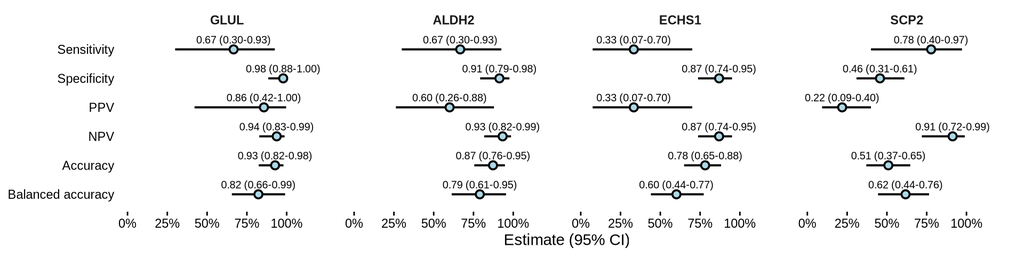

```r
write_xlsx(met_IPMN, "output/metrics_IPMN.xlsx")

p <- plot_metrics(met_IPMN, "lightblue"); p
```

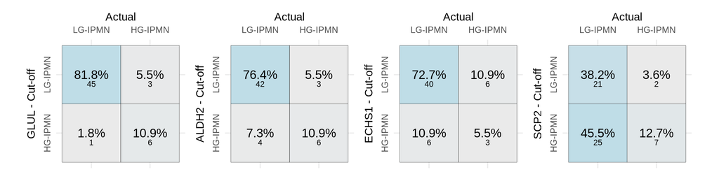

```r
svg("output/metrics_IPMN.svg", width = 7.5, height = 2.5); print(p); invisible(dev.off())

cm_plots <- lapply(MARKERS, plot_cm_marker, cutoffs = cutoffs_IPMN, data = df_val,
                   outcome = "malignant_IPMN", lab = LAB_IPMN, fill = "lightblue")
png("output/cm_Malignant_IPMN.png", width = 10, height = 2.5, res = 300, units = "in")
print(wrap_plots(cm_plots, ncol = 4)); invisible(dev.off())
png("output/cm_Malignant_IPMNv.png", width = 5, height = 5, res = 300, units = "in")
print(wrap_plots(cm_plots, ncol = 2)); invisible(dev.off())
wrap_plots(cm_plots, ncol = 4)
```

# 4. CA19-9 — binary comparison and complementarity

Restricted to validation patients with CA19-9 recorded (complete cases). GLUL is evaluated at its locked discovery cut-off; the “either-positive” rule calls a patient positive if GLUL or CA19-9 is positive. This is a complementarity analysis at fixed operating points, not a comparison of discrimination.

```r
df_val_cc <- subset(df_val, !is.na(ca19_pos))
table(df_val_cc$Type)
```

```
##
## High-Grade IPMN  Low-Grade IPMN            PDAC
##               8              42              10
```

```r
ca19_rule <- function(data, cutoffs, outcome, marker = "GLUL") {
  cut   <- cutoffs$youden_cut[cutoffs$marker == marker]
  cc    <- !is.na(data$ca19_pos) & !is.na(data[[outcome]])
  truth <- data[[outcome]][cc]
  mk    <- as.integer(data[[marker]][cc] >= cut)
  ca19  <- data$ca19_pos[cc]
  either <- as.integer(mk == 1 | ca19 == 1)

  neg_mal <- ca19 == 0 & truth == 1
  cat(sprintf("Complete cases: %d | %s-positive among CA19-9-negative malignant: %d of %d\n",
              sum(cc), marker, sum(mk[neg_mal] == 1), sum(neg_mal)))

  list(truth = truth, ca19 = ca19, marker = mk, either = either,
       metrics = rbind(metrics_from_pred(truth, ca19,   "CA19-9"),
                       metrics_from_pred(truth, mk,     marker),
                       metrics_from_pred(truth, either, paste0("Ca19-9 + ", marker))))
}
```

## Primary contrast — Figure 5D–E

```r
rule_PDAC <- ca19_rule(df_val_cc, cutoffs_PDAC, "malignant_PDAC")
```

```
## Complete cases: 60 | GLUL-positive among CA19-9-negative malignant: 5 of 7
```

```r
rule_PDAC$metrics
```

```
##        predictor            metric       est        lo        hi TP FN TN FP
## 1         CA19-9          Accuracy 0.8666667 0.7540778 0.9406356 11  7 41  1
## 2         CA19-9       Sensitivity 0.6111111 0.3574512 0.8270141 11  7 41  1
## 3         CA19-9       Specificity 0.9761905 0.8743414 0.9993974 11  7 41  1
## 4         CA19-9               PPV 0.9166667 0.6152038 0.9978924 11  7 41  1
## 5         CA19-9               NPV 0.8541667 0.7223617 0.9392955 11  7 41  1
## 6         CA19-9 Balanced accuracy 0.7936508 0.6816694 0.9062646 11  7 41  1
## 7           GLUL          Accuracy 0.9333333 0.8380132 0.9815382 15  3 41  1
## 8           GLUL       Sensitivity 0.8333333 0.5858225 0.9642149 15  3 41  1
## 9           GLUL       Specificity 0.9761905 0.8743414 0.9993974 15  3 41  1
## 10          GLUL               PPV 0.9375000 0.6976793 0.9984189 15  3 41  1
## 11          GLUL               NPV 0.9318182 0.8134380 0.9857123 15  3 41  1
## 12          GLUL Balanced accuracy 0.9047619 0.8095238 0.9886364 15  3 41  1
## 13 Ca19-9 + GLUL          Accuracy 0.9333333 0.8380132 0.9815382 16  2 40  2
## 14 Ca19-9 + GLUL       Sensitivity 0.8888889 0.6528796 0.9862488 16  2 40  2
## 15 Ca19-9 + GLUL       Specificity 0.9523810 0.8383580 0.9941802 16  2 40  2
## 16 Ca19-9 + GLUL               PPV 0.8888889 0.6528796 0.9862488 16  2 40  2
## 17 Ca19-9 + GLUL               NPV 0.9523810 0.8383580 0.9941802 16  2 40  2
## 18 Ca19-9 + GLUL Balanced accuracy 0.9206349 0.8315018 0.9891304 16  2 40  2
```

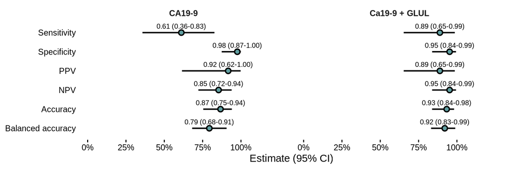

```r
write_xlsx(rule_PDAC$metrics, "output/metrics_CA19-9_GLUL_PDAC_cc.xlsx")

# Figure 5D shows CA19-9 alone and the either-positive rule
fig_df <- subset(rule_PDAC$metrics, predictor != "GLUL")
p <- plot_metrics(fig_df, "cadetblue"); p
```

```r
svg("output/metrics_c19_GLUL_PDAC_cc.svg", width = 5, height = 2.5); print(p); invisible(dev.off())

cms <- list(plot_cm(rule_PDAC$truth, rule_PDAC$ca19,   LAB_PDAC, "cadetblue", "CA19-9"),
            plot_cm(rule_PDAC$truth, rule_PDAC$either, LAB_PDAC, "cadetblue", "CA19-9 + GLUL"))
png("output/cm_ca19_GLUL_PDAC_cc.png", width = 5, height = 2.5, res = 300, units = "in")
print(wrap_plots(cms, ncol = 2)); invisible(dev.off())
```

## Secondary contrast — Supplementary Figure 5D–E

```r
rule_IPMN <- ca19_rule(df_val_cc, cutoffs_IPMN, "malignant_IPMN")
```

```
## Complete cases: 50 | GLUL-positive among CA19-9-negative malignant: 3 of 5
```

```r
rule_IPMN$metrics
```

```
##        predictor            metric       est         lo        hi TP FN TN FP
## 1         CA19-9          Accuracy 0.8800000 0.75689868 0.9546647  3  5 41  1
## 2         CA19-9       Sensitivity 0.3750000 0.08523341 0.7551368  3  5 41  1
## 3         CA19-9       Specificity 0.9761905 0.87434144 0.9993974  3  5 41  1
## 4         CA19-9               PPV 0.7500000 0.19412045 0.9936905  3  5 41  1
## 5         CA19-9               NPV 0.8913043 0.76430330 0.9637516  3  5 41  1
## 6         CA19-9 Balanced accuracy 0.6755952 0.48936170 0.8572917  3  5 41  1
## 7           GLUL          Accuracy 0.9200000 0.80765722 0.9777720  5  3 41  1
## 8           GLUL       Sensitivity 0.6250000 0.24486322 0.9147666  5  3 41  1
## 9           GLUL       Specificity 0.9761905 0.87434144 0.9993974  5  3 41  1
## 10          GLUL               PPV 0.8333333 0.35876542 0.9957893  5  3 41  1
## 11          GLUL               NPV 0.9318182 0.81343799 0.9857123  5  3 41  1
## 12          GLUL Balanced accuracy 0.8005952 0.61111111 0.9883721  5  3 41  1
## 13 Ca19-9 + GLUL          Accuracy 0.9200000 0.80765722 0.9777720  6  2 40  2
## 14 Ca19-9 + GLUL       Sensitivity 0.7500000 0.34914421 0.9681460  6  2 40  2
## 15 Ca19-9 + GLUL       Specificity 0.9523810 0.83835804 0.9941802  6  2 40  2
## 16 Ca19-9 + GLUL               PPV 0.7500000 0.34914421 0.9681460  6  2 40  2
## 17 Ca19-9 + GLUL               NPV 0.9523810 0.83835804 0.9941802  6  2 40  2
## 18 Ca19-9 + GLUL Balanced accuracy 0.8511905 0.66369048 0.9888889  6  2 40  2
```

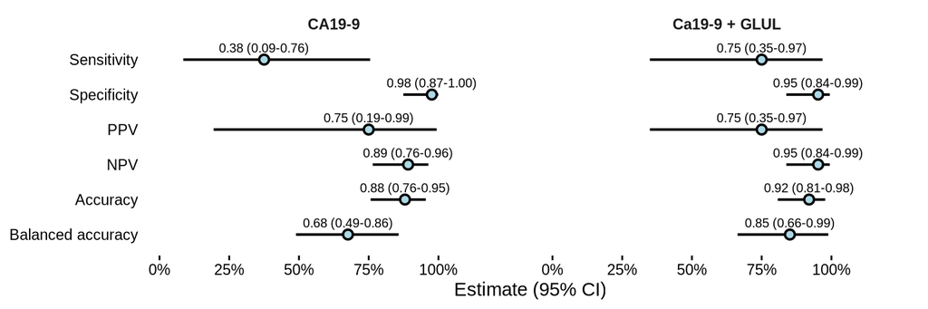

```r
write_xlsx(rule_IPMN$metrics, "output/metrics_CA19-9_GLUL_IPMN_cc.xlsx")

fig_df <- subset(rule_IPMN$metrics, predictor != "GLUL")
p <- plot_metrics(fig_df, "lightblue"); p
```

```r
svg("output/metrics_ca19_GLUL_IPMN_cc.svg", width = 5, height = 2.5); print(p); invisible(dev.off())

cms <- list(plot_cm(rule_IPMN$truth, rule_IPMN$ca19,   LAB_IPMN, "lightblue", "CA19-9"),
            plot_cm(rule_IPMN$truth, rule_IPMN$either, LAB_IPMN, "lightblue", "CA19-9 + GLUL"))
png("output/cm_ca19_GLUL_IPMN_cc.png", width = 5, height = 2.5, res = 300, units = "in")
print(wrap_plots(cms, ncol = 2)); invisible(dev.off())
```